# 3.3 Probability Distributions

## Disjoint Events

Two outcomes are **disjoint** or **mutually exclusive** if they cannot both happen (at the same time).

- This is like nonoverlapping bins for histograms.

> *Example*: If I roll a six-sided die one time, rolling a 5 and rolling a 6 are disjoint. I can get a 5 *or* a 6, but not both on the same roll.

> *Example*: If I select a student, they can be a freshman *or* a sophomore, but that student cannot be both a freshman and a sophomore at the same time.

## Checkpoint

Determine whether the following events are mutually exclusive (disjoint).

1. Your friend studies in the library. You study at home.
2. You and your study group all earn As on an exam.
3. You stay out until 3 am. You go to bed at 9 pm.

## Venn Diagrams

**Venn Diagrams** show events as circles. The circles overlap where events share common outcomes.

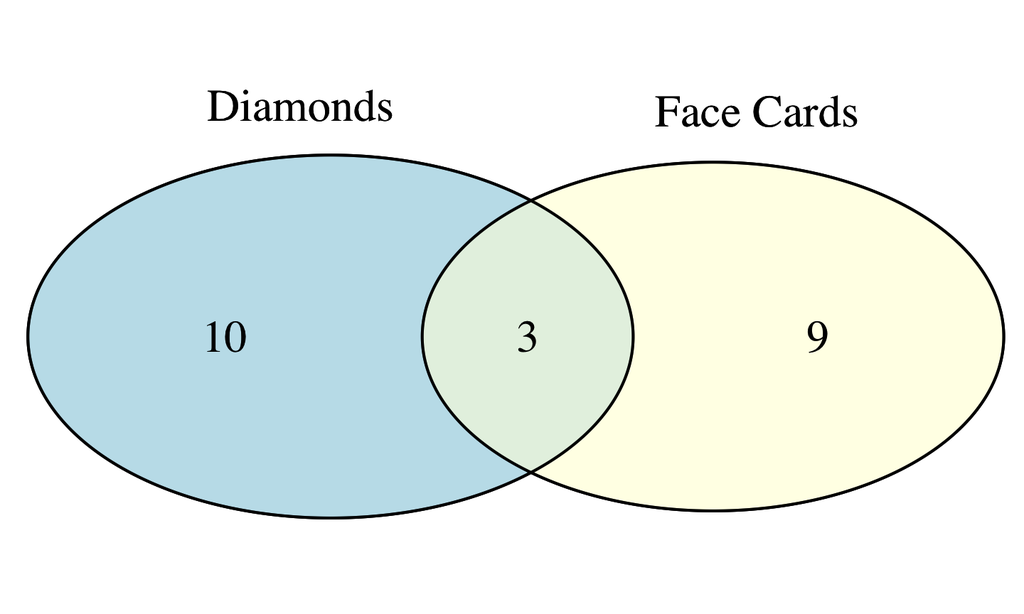

- When a Venn Diagram has *no overlap* the events are mutually exclusive.
- Consider the event “Draw a Diamond” and the event “Draw a Face Card”.
- There are 13 diamonds and 12 face cards in a deck.
- The events are *not* mutually exclusive:
  - it’s possible to draw both a diamond and a face card at the same time: the Jack of Diamonds, Queen of Diamonds, and King of Diamonds.

## Checkpoint

Consider events

- \(A\): “Draw a spade”
- \(B\): “Draw a queen”
- \(C\): “Draw a red”

Which of these events are mutually exclusive?

## Checkpoint

In a group of 24 people, 13 have cats and 15 have dogs. Four of them have both cats and dogs. Sketch a Venn Diagram for these events.

## Probability Distributions

A **probability distribution** lists all possible disjoint outcomes and their associated probabilities.

| Roll of a six-sided die | 1 | 2 | 3 | 4 | 5 | 6 |
| --- | --- | --- | --- | --- | --- | --- |
| Probability | 1/6 | 1/6 | 1/6 | 1/6 | 1/6 | 1/6 |

## Probability Axioms

The **probability axioms** are requirements for a valid probability distribution. They are:

1. All listed outcomes must be disjoint.
2. Each probability must be between 0 and 1.
3. The probabilities must sum to 1.
- #2 is true for ALL probabilities.
- If you ever calculate a probability and get a negative number or a number greater than 1, something went wrong!

## Checkpoint

Use the probability axioms to check whether the following tables are probability distributions.

A

| X | {1 or 2} | {3 or 4} | {5 or 6} |
| --- | --- | --- | --- |
| P(X) | 1/3 | 1/3 | 1/3 |

B

| Y | {1 or 2} | {2 or 3} | {3 or 4} | {5 or 6} |
| --- | --- | --- | --- | --- |
| P(Y) | 1/3 | 1/3 | 1/3 | -1/3 |

## Probability Distributions and Relative Frequency

- Probability distributions look a lot like relative frequency distributions.
- This isn’t a coincidence!
- A relative frequency distribution is a good way to use data to approximate a probability distribution.